# Make inverse distance weighted maps using akgfmaps

Sean Rohan

## Introduction

This vignette demonstrates how to create IDW maps using akgfmaps. If you haven’t installed akgfmaps already, follow the installation instructions on the . Then, load the akgfmaps package.

```r
library(akgfmaps)
```

The package and all of the dependencies should load. If they do not, make sure you are running R >= 3.6, and verify that all of the dependencies listed in the file are installed.

## Documentation

Function documentation is accessible using the standard R convention (e.g. documentation for can be accessed using ).

```r
?make_idw_map
```

## Make IDW maps

Start by loading and inspecting the 2017 EBS and NBS yellowfin sole CPUE data that is included with the package.

```r
# Load 2017 EBS and NBS yellowfin sole data
yfs2017 <- akgfmaps::YFS2017
head(yfs2017)
```

```
##      COMMON_NAME YEAR HAUL STATIONID LATITUDE LONGITUDE CPUE_KGHA
## 1 yellowfin sole 2017  110      C-18 55.65603 -168.1808         0
## 2 yellowfin sole 2017  109      B-01 55.35203 -167.5591         0
## 3 yellowfin sole 2017  108      C-01 55.67721 -167.5877         0
## 4 yellowfin sole 2017  194      M-27 58.99964 -174.3394         0
## 5 yellowfin sole 2017  199      O-29 59.66879 -175.8888         0
## 6 yellowfin sole 2017  200      P-29 59.98190 -175.9443         0
```

The data includes the species common name, year, station id, latitude, longitude, and catch-per-unit effort in kilograms per hectare. At minimum, the data must include latitude, longitude, and catch-per-unit effort data to plot CPUE.

The function for performing the IDW and making a plot is . The function uses gstat to perform the IDW, then raster, stars, and sf for plotting. As arguments to the function, Users can specify:

- The domain for IDW and mapping, using the ‘region’ argument. Currently, maps can automatically be generated standard EBS shelf survey area (region = “bs.south”) and full EBS shelf (region = “bs.all”).
- Set break points for plotting, manually or algorithmically, using the ‘set.breaks’ argument. This can be a numeric vector of breaks (manual) or a character vector passed to \code{classInt::classIntervals) to algorithmically define breaks.
- Generate a custom extrpolation domain for the output. This is automatically generated for “bs.south” and “bs.all”
- The resolution of the extrapolation grid using the ‘grid.cell’ argument. Extrpolation takes longer for riner resolution grids.
- Add a key.title (e.g. species name).
- Define an input coordinate reference system. Retain the default setting if input is in degrees latitude and longitude.
- Define an output coordinate reference system that will be used for plotting (defaults to Albers Equal Area).
- Set the number of ‘neighbor’ points used for IDW. Defaults to 4, more neighbors takes longer to run.
- Data can be passed to the function using a data.frame or vectors. If using a data.frame, column names need to include CPUE_KGHA, LATITUDE, and LONGITUDE.

See function documentation for default arguments.

```r
opt1 <- make_idw_map(x = yfs2017, # Pass data as a data frame
             region = "bs.all", # Predefined bs.all area
             set.breaks = "jenks", # Gets Jenks breaks from classint::classIntervals()
             grid.cell = c(0.02, 0.02), # 0.2x0.2 degree grid cells
             key.title = "yellowfin sole") # Include yellowfin sole in the legend title
```

```
## [inverse distance weighted interpolation]
```

```
## [inverse distance weighted interpolation]
```

The function returns a list containing object which contain information about the region, number of breaks, and key.title, which are used by other functions to manipulate plots and add labels.

```r
opt1$region
```

```
## [1] "bs.all"
```

```r
opt1$n.breaks
```

```
## [1] 6
```

```r
opt1$key.title
```

```
## [1] "yellowfin sole"
```

Another object in the list is a extrapolation grid (a ‘stars’ object) which can be used to make plots outside of akgfmaps, but also retains the crs for plotting.

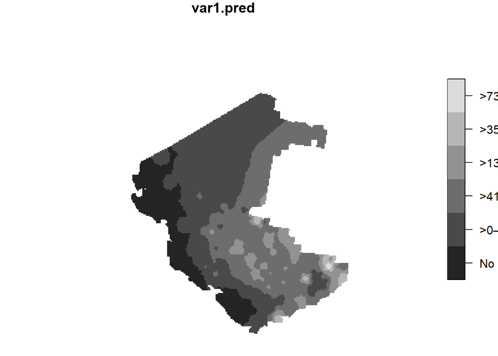

```r
plot(opt1$extrapolation.grid)
```

```r
st_crs(opt1$extrapolation.grid)
```

```
## Coordinate Reference System:
##   No EPSG code
##   proj4string: "+proj=aea +lat_1=55 +lat_2=65 +lat_0=50 +lon_0=-154 +x_0=0 +y_0=0 +ellps=GRS80 +towgs84=0,0,0,0,0,0,0 +units=m +no_defs"
```

```r
class(opt1$extrapolation.grid)
```

```
## [1] "stars"
```

The last object in the list is a ggplot object.

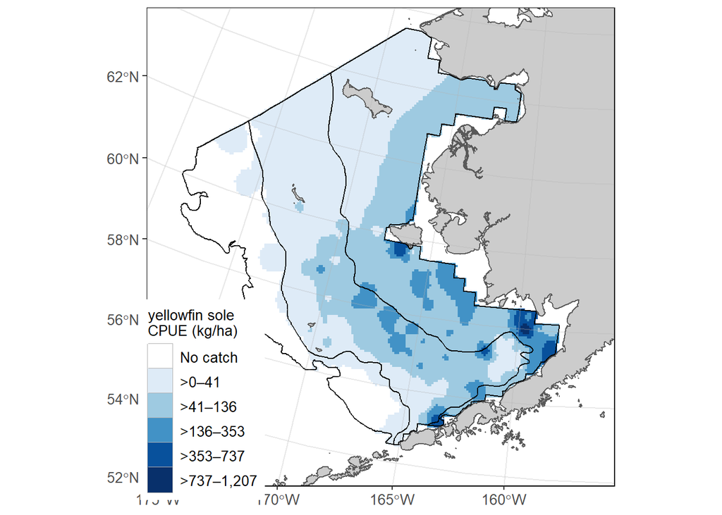

```r
opt1$plot
```

Map layers are included in the package and do not need to be provided separately. Changes to text sizing, color palette, and addition of plot labels is done using change_text_size, change_fill_color, and add_idw

## Changing colors

The function changes the fill color palette using predefined color palettes. Refer to the function documentation for a list of colors. Below, I show two transformations, one to grey scale and one to red, using pipe operators \code{%>%} and passing the new fill color to the argument. If no argument is provided to new.scheme, a color palette selector tool will open in a separate window . The predefined color palettes are colorblind and grayscale friendly.

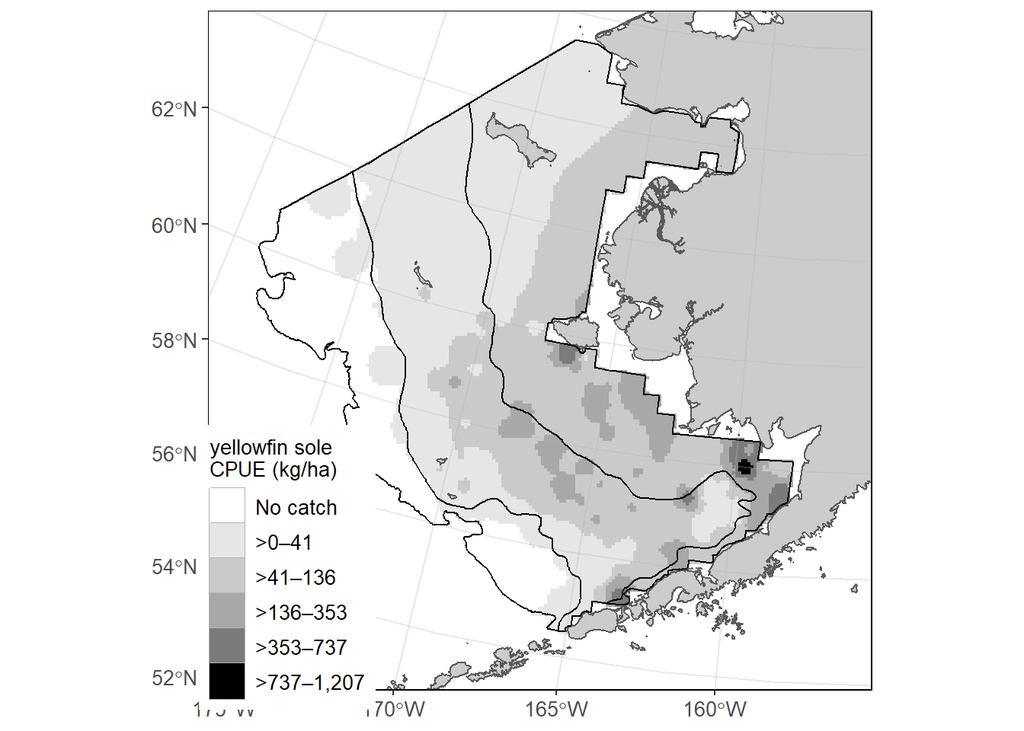

```r
# Grey Note that the WHOLE list that was returned by make_idw_map should be passed to the function.
opt1.grey <- opt1 %>% change_fill_color(new.scheme = "grey", show.plot = FALSE)

# Red
opt1.red <- opt1 %>% change_fill_color(new.scheme = "red", show.plot = FALSE)

opt1.grey$plot
```

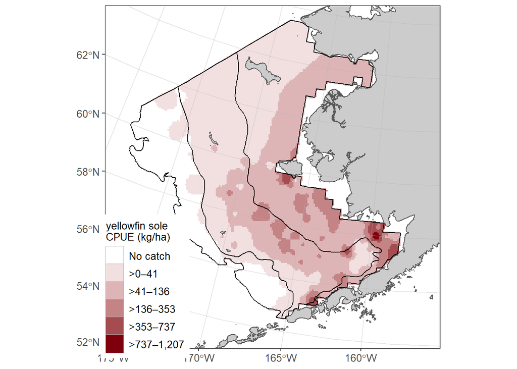

```r
opt1.red$plot
```

The returned list objects retain the same structure as the objects from make_idw_map

## Adding labels

Labels can be added by passing a data frame of labels, locations, and label types to the function. Alternatively, pre-defined labels can be added to the plot based on the region. Below, pre-defined labels are added to the plot using and . Below, labels and a scale bar are added to the greyscale plot using pre-defined settings based on the plot region.

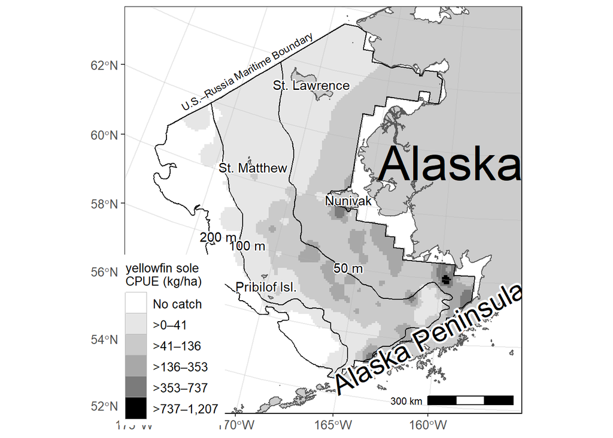

```r
opt1.grey <- opt1.grey %>% add_map_labels()
opt1.grey$plot
```

Custom labels can also be appended to the object, with sizing and orientation based on defined ‘types.’ In the example below, a data frame is passed with plotting locations. Internally, the function transforms long/lat coordinates in eastings to the Albers Equal Area projection of the map. See function documentation for options to turn on/off spatial transformations.

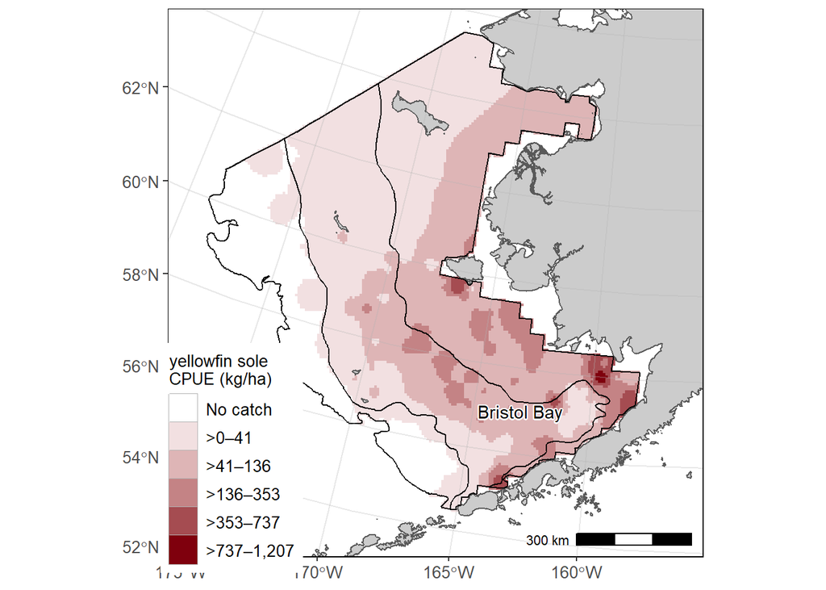

```r
# ONLY custom label
opt1.red2 <- opt1.red %>% add_map_labels(new.places = data.frame(type = "islands", region = "bs.all", x = -163, y = 57, lab = "Bristol Bay"), lab.replace = TRUE)
opt1.red2$plot
```

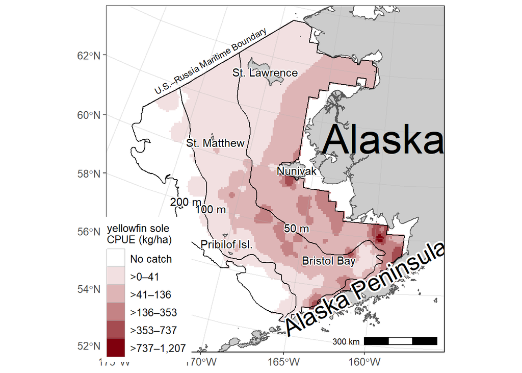

```r
# Add custom label
opt1.red <- opt1.red %>% add_map_labels(new.places = data.frame(type = "islands", region = "bs.all", x = -163, y = 57, lab = "Bristol Bay"), lab.replace = FALSE)
opt1.red$plot
```

## Create map file

After labels and colors are added to the map, the function can be used to create publication-quality png files. It automatically rescales axis and text labels for some pre-defined plot sizes. Output file names can be specified using file.prefix, or they will be extracted automatically from the input list. The function passes plotting arguments to . The argument indicates whether the function should try to resize text based on a pre-defined scaling factor.

```r
opt1.grey %>%
create_map_file(width = 8, # Passed to png()
                height = 6,  # Passed to png()
                units = "in",  # Passed to png()
                res = 300,  # Passed to png()
                bg = "transparent", # Passed to png()
                file.path = "./",
                try.change_text_size = TRUE)
```

```
## [1] "Creating map ./yellowfin sole_8x6.png"
```

## Resizing text

If the desired size for the map is not pre-defined, the function can be used resize plot text prior to creating a map.

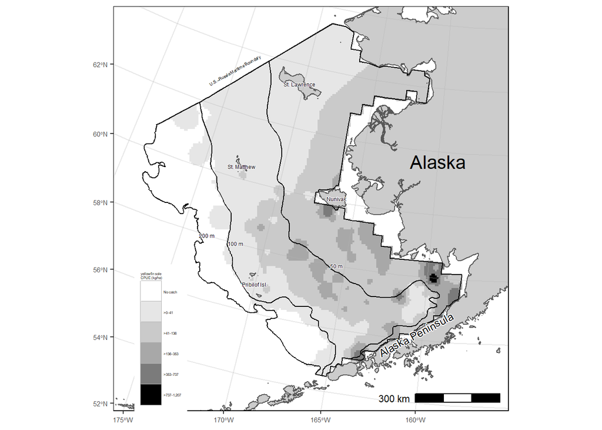

```r
opt.grey2 <- opt1.grey %>% change_text_size(size.mult = 0.5)
opt.grey2$plot
```

## Exploring break options

See the breaks vignette for details.